# CNN_Cat_v_dog_colab

### Convolutional Neural Network (CNN) to identify images of Cats v. Dogs

The goal of this project is to use a CNN on Google Colab (because I need access to an Nvidia GPU) to train a model that can correctly identify a dog versus a cat. This project is mostly a challenge since dogs and cats are small furry animals and CNNs typically struggle with such close categories (dataset is from Kaggle). I also wanted to further explore using GPU computing.

The orginal dataset contains images of a variety of sizes, which first had to be scaled down. In order to save on compute time and memory I decided to scale everything down to 200 by 200. The scaling did deform the aspect ratio of some images, however, this will likely only aid in building a more robust model.

Overall, the modeling performed here can be expanded out into a variety of computer vision areas. For example, CNNs have been used to quickly detect if a cell is infected with malaria.

```
['training_set', 'test_set']
```

### Images are all scaled to be the same dimensions.

```
Image 1: (200, 200, 3)
Image 2: (200, 200, 3)
```

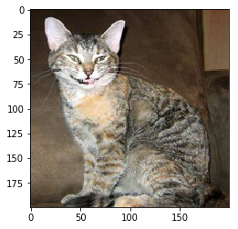

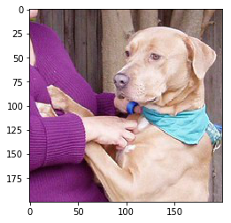

### The training set has 4,000 dog and cat images each

```
Number of cat images: 4000
Number of dog images: 4000
```

### So as to keep the CNN robust, I will also randomly deform the images by zooming, flipping, etc.

This is also a great way to increase the sample size

Note dog from before is horizontally flipped.

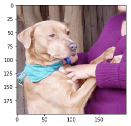

### Data flow for training set

```
Found 8000 images belonging to 2 classes.
```

```
<keras_preprocessing.image.directory_iterator.DirectoryIterator at 0x7f1a136d7860>
```

### Data flow for test set

```
Found 2000 images belonging to 2 classes.
```

```
<keras_preprocessing.image.directory_iterator.DirectoryIterator at 0x7f1a136d7fd0>
```

### Even after scaling the images down I will set the target size to something even smaller (because compute times were still very long) to 128 by 128.

```
Found 8000 images belonging to 2 classes.
```

```
Found 2000 images belonging to 2 classes.
```

```
Model: "sequential_2"
_________________________________________________________________
Layer (type)                 Output Shape              Param #
=================================================================
conv2d_4 (Conv2D)            (None, 124, 124, 32)      2432
_________________________________________________________________
max_pooling2d_4 (MaxPooling2 (None, 62, 62, 32)        0
_________________________________________________________________
conv2d_5 (Conv2D)            (None, 58, 58, 32)        25632
_________________________________________________________________
max_pooling2d_5 (MaxPooling2 (None, 29, 29, 32)        0
_________________________________________________________________
flatten_2 (Flatten)          (None, 26912)             0
_________________________________________________________________
dense_4 (Dense)              (None, 128)               3444864
_________________________________________________________________
dropout_2 (Dropout)          (None, 128)               0
_________________________________________________________________
dense_5 (Dense)              (None, 1)                 129
=================================================================
Total params: 3,473,057
Trainable params: 3,473,057
Non-trainable params: 0
_________________________________________________________________
```

### Cats are coded as 0 and dogs are coded as 1

```
{'cats': 0, 'dogs': 1}
```

```
WARNING:tensorflow:sample_weight modes were coerced from
  ...
    to
  ['...']
WARNING:tensorflow:sample_weight modes were coerced from
  ...
    to
  ['...']
Train for 250 steps, validate for 63 steps
```

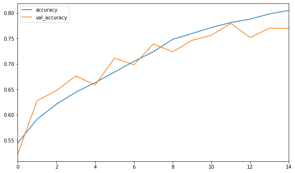

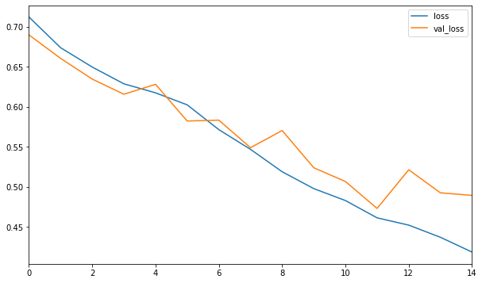

### Model has decent f1-scores, however I would like to test it on a real image

```
              precision    recall  f1-score   support

           0       0.78      0.78      0.78      1000
           1       0.78      0.78      0.78      1000

    accuracy                           0.78      2000
   macro avg       0.78      0.78      0.78      2000
weighted avg       0.78      0.78      0.78      2000
```

### Well, the model certainly predicted this one incorrectly

```
predicted answer: Dog
```

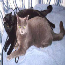

### The model did predict this one correctly

```
predicted answer: Cat
```

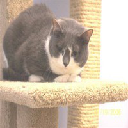

### The plots from below indicate that the training process is a bit noisy, so I will increase the patience for Early Stopping and add in dropouts to turn off some of the units.

```
Model: "sequential_6"
_________________________________________________________________
Layer (type)                 Output Shape              Param #
=================================================================
conv2d_15 (Conv2D)           (None, 126, 126, 32)      896
_________________________________________________________________
max_pooling2d_15 (MaxPooling (None, 63, 63, 32)        0
_________________________________________________________________
dropout_15 (Dropout)         (None, 63, 63, 32)        0
_________________________________________________________________
conv2d_16 (Conv2D)           (None, 61, 61, 64)        18496
_________________________________________________________________
max_pooling2d_16 (MaxPooling (None, 30, 30, 64)        0
_________________________________________________________________
dropout_16 (Dropout)         (None, 30, 30, 64)        0
_________________________________________________________________
conv2d_17 (Conv2D)           (None, 28, 28, 128)       73856
_________________________________________________________________
max_pooling2d_17 (MaxPooling (None, 14, 14, 128)       0
_________________________________________________________________
dropout_17 (Dropout)         (None, 14, 14, 128)       0
_________________________________________________________________
flatten_6 (Flatten)          (None, 25088)             0
_________________________________________________________________
dense_12 (Dense)             (None, 128)               3211392
_________________________________________________________________
dropout_18 (Dropout)         (None, 128)               0
_________________________________________________________________
dense_13 (Dense)             (None, 1)                 129
=================================================================
Total params: 3,304,769
Trainable params: 3,304,769
Non-trainable params: 0
_________________________________________________________________
WARNING:tensorflow:sample_weight modes were coerced from
  ...
    to
  ['...']
WARNING:tensorflow:sample_weight modes were coerced from
  ...
    to
  ['...']
Train for 250 steps, validate for 63 steps
```

### This model is performing far better than the previous model. The validation accuracy and loss curves also mostly appear to have flattened out. The noise in both still suggests that if I increased my patience for early stopping to 8 or 10, I may still be able to improve the model. Overall, I could keep tweaking the parameters, but this model is fairly succesful at identifying dogs from cats. I have saved the model to github if there is any interest in tweaking it further.

```
              precision    recall  f1-score   support

           0       0.83      0.93      0.87      1000
           1       0.92      0.81      0.86      1000

    accuracy                           0.87      2000
   macro avg       0.87      0.87      0.87      2000
weighted avg       0.87      0.87      0.87      2000
```

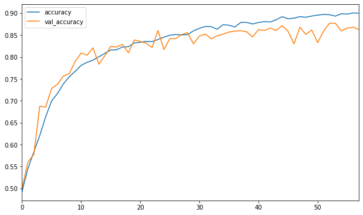

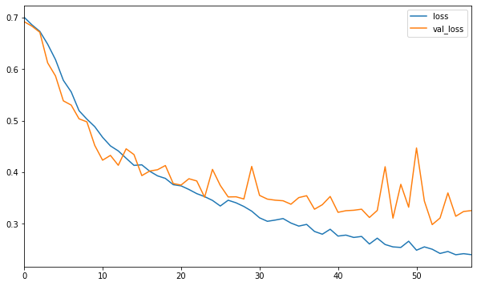

|  | 0 | 1 |
| --- | --- | --- |
| 0 | 926 | 74 |
| 1 | 191 | 809 |

```
predicted answer: Cat
```

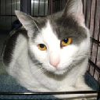

```
predicted answer: Dog
```

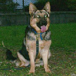